# Lab4: Avocado Prices

Author

Sebastian Boksem

## Declaring Libraries

```r
library(tidyverse)
```

## Importing Data Set

```r
avocado <- read_csv(here::here("supporting_artifacts", "Lab4", "avocado.csv"))
```

```r
dim(avocado)
```

```
[1] 18249    14
```

```r
str(avocado)
```

```
spc_tbl_ [18,249 × 14] (S3: spec_tbl_df/tbl_df/tbl/data.frame)
 $ ...1        : num [1:18249] 0 1 2 3 4 5 6 7 8 9 ...
 $ Date        : Date[1:18249], format: "2015-12-27" "2015-12-20" ...
 $ AveragePrice: num [1:18249] 1.33 1.35 0.93 1.08 1.28 1.26 0.99 0.98 1.02 1.07 ...
 $ Total Volume: num [1:18249] 64237 54877 118220 78992 51040 ...
 $ 4046        : num [1:18249] 1037 674 795 1132 941 ...
 $ 4225        : num [1:18249] 54455 44639 109150 71976 43838 ...
 $ 4770        : num [1:18249] 48.2 58.3 130.5 72.6 75.8 ...
 $ Total Bags  : num [1:18249] 8697 9506 8145 5811 6184 ...
 $ Small Bags  : num [1:18249] 8604 9408 8042 5677 5986 ...
 $ Large Bags  : num [1:18249] 93.2 97.5 103.1 133.8 197.7 ...
 $ XLarge Bags : num [1:18249] 0 0 0 0 0 0 0 0 0 0 ...
 $ type        : chr [1:18249] "conventional" "conventional" "conventional" "conventional" ...
 $ year        : num [1:18249] 2015 2015 2015 2015 2015 ...
 $ region      : chr [1:18249] "Albany" "Albany" "Albany" "Albany" ...
 - attr(*, "spec")=
  .. cols(
  ..   ...1 = col_double(),
  ..   Date = col_date(format = ""),
  ..   AveragePrice = col_double(),
  ..   `Total Volume` = col_double(),
  ..   `4046` = col_double(),
  ..   `4225` = col_double(),
  ..   `4770` = col_double(),
  ..   `Total Bags` = col_double(),
  ..   `Small Bags` = col_double(),
  ..   `Large Bags` = col_double(),
  ..   `XLarge Bags` = col_double(),
  ..   type = col_character(),
  ..   year = col_double(),
  ..   region = col_character()
  .. )
 - attr(*, "problems")=<externalptr>
```

This data set seems to contain the total volume of three different price lookup’s of avocados sold in different stores. In addition to this, the data, type (whether it is organic or conventional), the year, region, and average price is included. There seems to be character, dates, and non-integer data type values. Overall, there seems to be 18249 rows with 14 columns. 4046 represents Small Hass, 4225 represents Large Hass, 4770 represents extra large avocados.

```r
major_region <- c('Northeast', 'Southeast', 'SouthCentral', 'Plains', 'West', 'Midsouth', 'GreatLakes')
major_state <- c('NewYork', 'California', 'SouthCarolina', 'WestTexNewMexico')
california_cities <- c('LosAngeles', 'SanDiego', 'Sacramento', 'SanFrancisco')
total_us <- c('TotalUS')
major_region <- data.frame(major_region)
major_state <- data.frame(major_state)
california_cities <- data.frame(california_cities)
total_us <- data.frame(total_us)
avocado_major_region <- avocado |>
  semi_join(major_region, by = c('region' = 'major_region'))
avocado_no_major_region <- avocado |>
  anti_join(major_region, by = c('region' = 'major_region'))
avocado_no_major_region_or_state <- avocado_no_major_region |>
  anti_join(major_state, by = c('region' = 'major_state'))
avocado_metro_cities <- avocado_no_major_region_or_state |>
  anti_join(total_us, by = c('region' = 'total_us'))
avocado_total_us <- avocado |>
  semi_join(total_us, by = c('region' = 'total_us'))
avocado_california <- avocado |>
  semi_join(california_cities, by = c('region' = 'california_cities'))
```

**REFELCTION:**

**Upon looking back on this question, I think the overall application of chaining and piping all the anti joins together is important because it shows how exactly this joins can be used to clean data in a faster way. Also it is important to include the states Minnesota and Michigan and I’ve added the great lakes to the region. For the future I will chain the anti-joins to optimize the code. I’ve added a new section below in which I have done this:**

```r
avocado |>
  anti_join(major_region, by = c('region' = 'major_region')) |>
  anti_join(major_state, by = c('region' = 'major_state')) |>
  filter(region != 'TotalUS') |>
  rename("Small" =  `4046`,
         "Large" =  `4225`,
         "Extra Large" = `4770`)
```

```
# A tibble: 14,196 × 14
    ...1 Date       Avera…¹ Total…² Small  Large Extra…³ Total…⁴ Small…⁵ Large…⁶
   <dbl> <date>       <dbl>   <dbl> <dbl>  <dbl>   <dbl>   <dbl>   <dbl>   <dbl>
 1     0 2015-12-27    1.33  64237. 1037. 5.45e4    48.2   8697.   8604.    93.2
 2     1 2015-12-20    1.35  54877.  674. 4.46e4    58.3   9506.   9408.    97.5
 3     2 2015-12-13    0.93 118220.  795. 1.09e5   130.    8145.   8042.   103.
 4     3 2015-12-06    1.08  78992. 1132  7.20e4    72.6   5811.   5677.   134.
 5     4 2015-11-29    1.28  51040.  941. 4.38e4    75.8   6184.   5986.   198.
 6     5 2015-11-22    1.26  55980. 1184. 4.81e4    43.6   6684.   6556.   127.
 7     6 2015-11-15    0.99  83454. 1369. 7.37e4    93.3   8319.   8197.   122.
 8     7 2015-11-08    0.98 109428.  704. 1.02e5    80     6829.   6267.   562.
 9     8 2015-11-01    1.02  99811. 1022. 8.73e4    85.3  11388.  11105.   284.
10     9 2015-10-25    1.07  74339.  842. 6.48e4   113     8626.   8061.   564.
# … with 14,186 more rows, 4 more variables: `XLarge Bags` <dbl>, type <chr>,
#   year <dbl>, region <chr>, and abbreviated variable names ¹AveragePrice,
#   ²`Total Volume`, ³`Extra Large`, ⁴`Total Bags`, ⁵`Small Bags`,
#   ⁶`Large Bags`
```

## 3.

```r
avocado_major_region |>
  filter(
    type == 'organic',
    year == 2017
  ) |>
  group_by(region) |>
  summarize(total = sum(`4046`)) |>
slice_max(total)
```

```
# A tibble: 1 × 2
  region    total
  <chr>     <dbl>
1 West   1870206.
```

It appears that the West sold the most organic, small Hass avocados in 2017. They sold 1,870,206 avocados.

## 4.

```r
avocado_total_us |>
  separate(col = Date, into = c('Year', 'Month', 'Day'), sep = '-') |>
  group_by(Month) |>
  summarize(total = sum(as.numeric(`Total Volume`))) |>
slice_max(total)
```

```
# A tibble: 1 × 2
  Month      total
  <chr>      <dbl>
1 02    665625110.
```

It appears that month 2, or February, has sold the most volume of avocados. They sold 665,625,110 avocados.

## 5.

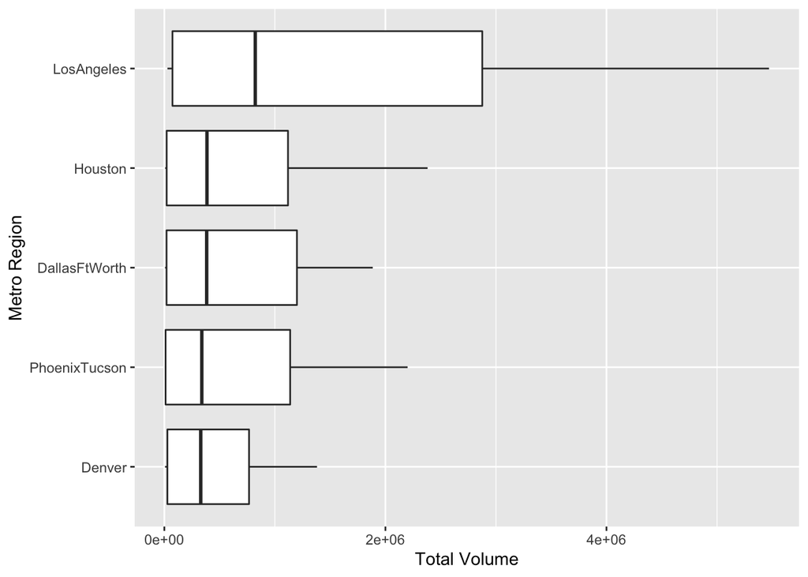

```r
avocado_metro_cities |>
  group_by(region) |>
  summarize(average = mean(`Total Volume`)) |>
  slice_max(average, n = 5)  |>
  select(region) |>
  left_join(avocado, by = 'region') |>
  ggplot(
       mapping = aes(y = reorder(region, `Total Volume`, median),
                     x = `Total Volume`,
                     )
                     ) + geom_boxplot() +
  labs(x = "Total Volume", y = "Metro Region")
```

## 6.

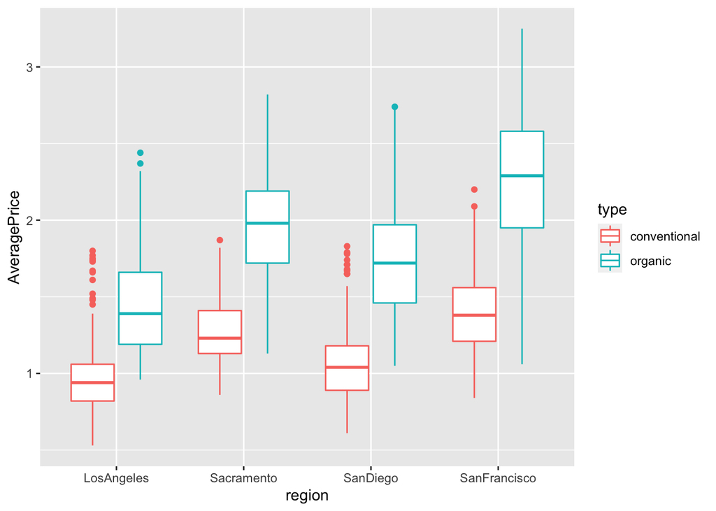

```r
#avocado_california |>
# group_by(region, type) |>
#  summarize(avg = mean(AveragePrice))  |>
#  pivot_wider(names_from = type, values_from = avg) |>
#  mutate(difference = conventional - organic)

avocado_california |>
  group_by(region, type) |>
  summarize(avg = mean(AveragePrice)) |>
  select(region, type) |>
  left_join(avocado, by = c('region' = 'region', 'type' = 'type')) |>
   ggplot(
       mapping = aes(y = AveragePrice,
                     x = region,
                     color = type
                     )
                     ) + geom_boxplot()
```

```r
#avocado_california |>
#  group_by(region, type) |>
#  summarize(median_avocado = median(AveragePrice))  |>
#  pivot_wider(names_from = type, values_from = median_avocado) |>
#  mutate(difference = conventional - organic)
```

## 7.

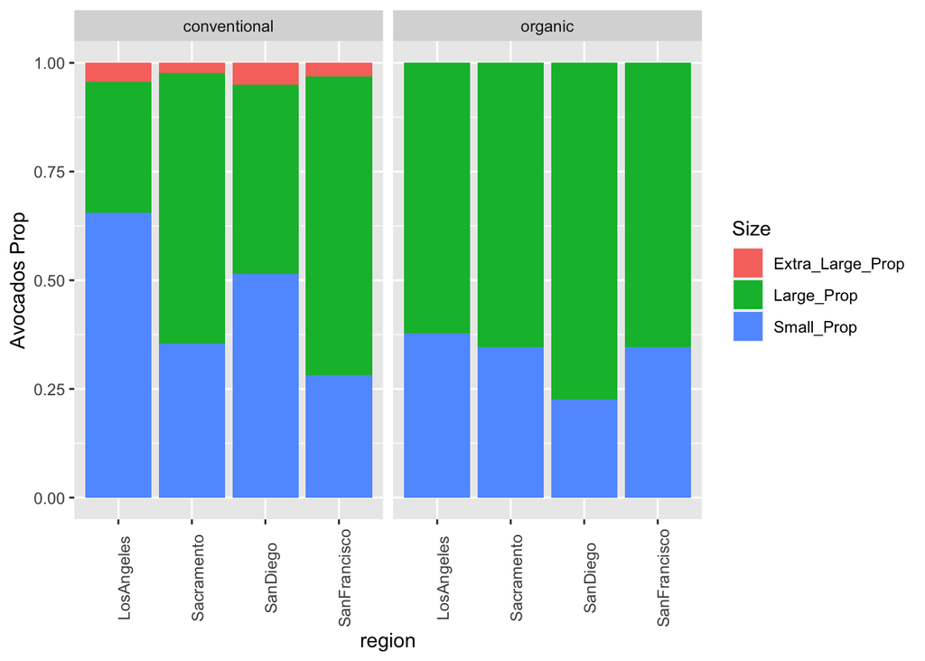

```r
avocado_california |>
  rename("Small" =  `4046`,
         "Large" =  `4225`,
         "Extra Large" = `4770`) |>
  mutate(total = Small + Large + `Extra Large`,
         Small_Prop = Small / total,
         Large_Prop = Large / total,
        EXL_Prop = `Extra Large` / total) |>
  group_by(region,type) |>
  summarize(Small_Prop = mean(Small_Prop),
            Large_Prop = mean(Large_Prop),
            Extra_Large_Prop = mean(EXL_Prop)) |>
pivot_longer(`Small_Prop`:`Extra_Large_Prop`,
               names_to = "Size",
               values_to = "Avocados Prop") |>
  ggplot() + geom_col(mapping = aes(x = region,y = `Avocados Prop`, fill = Size)) + facet_grid(. ~ type) +
  theme(axis.text.x = element_text(angle = 90))
```